# GPU Setup

```python
gpu_info = !nvidia-smi
gpu_info = '\n'.join(gpu_info)
if gpu_info.find('failed') >= 0:
  print('Not connected to a GPU')
else:
  print(gpu_info)

from psutil import virtual_memory
ram_gb = virtual_memory().total / 1e9
print('Your runtime has {:.1f} gigabytes of available RAM\n'.format(ram_gb))

if ram_gb < 20:
  print('Not using a high-RAM runtime')
else:
  print('You are using a high-RAM runtime!')
```

```
Thu Apr 13 18:47:21 2023
+-----------------------------------------------------------------------------+
| NVIDIA-SMI 525.85.12    Driver Version: 525.85.12    CUDA Version: 12.0     |
|-------------------------------+----------------------+----------------------+
| GPU  Name        Persistence-M| Bus-Id        Disp.A | Volatile Uncorr. ECC |
| Fan  Temp  Perf  Pwr:Usage/Cap|         Memory-Usage | GPU-Util  Compute M. |
|                               |                      |               MIG M. |
|===============================+======================+======================|
|   0  Tesla T4            Off  | 00000000:00:04.0 Off |                    0 |
| N/A   34C    P8     9W /  70W |      0MiB / 15360MiB |      0%      Default |
|                               |                      |                  N/A |
+-------------------------------+----------------------+----------------------+

+-----------------------------------------------------------------------------+
| Processes:                                                                  |
|  GPU   GI   CI        PID   Type   Process name                  GPU Memory |
|        ID   ID                                                   Usage      |
|=============================================================================|
|  No running processes found                                                 |
+-----------------------------------------------------------------------------+
Your runtime has 27.3 gigabytes of available RAM

You are using a high-RAM runtime!
```

# Introduction

## What is Operator Learning

**Map Between Finite Dimensional Vector Spaces Shall Be Called Functions**

*Example:*

Let $f_1(x)= \sin(x)$; for $x\in\mathbf{R}$

**Maps Between Infinite Dimensional Function Spaces Shall Be Called Operators**

$$G(f_1)=f_2$$

*Example:*

Consider the derivative operator, $\frac{d}{d x}$

Let $f_1(x)= \sin(x)$

Then when we apply our operator:

$$f_2=\frac{df_1(x)}{d x}=\frac{d}{d x}\sin(x)= \cos(x)$$

**Parametric PDEs and Operators**

Parametric PDEs $\rightarrow$ Some parameters (e.g., shape, IC/BC, coefficients, etc.) of a given PDE system are allowed to change.

Let $\mathcal{N}$ be a nonlinear differential operator.

Corresponding to it let's consider parametric PDEs of the form,

$$\mathcal{N}(f,u)=0$$

Our PDE solution operator would be a map $G$ s.t,

$$G(f)=u$$

In other words, we can express the general solution of our PDE as an operator $G$

$$G(f)(y)=u(y)\in \mathbf{R}$$

###### **Universal Approximation Theorem for Shallow Operator Nets**

$\forall \epsilon >0$, there are positive integers $n,p,m$, constants $c_i^k,W_{bij}^k,b_{bij}^k,W_{tk},b_{tk}$ such that:

$$\left|G(f)(y)-\sum_{k=1}^{p}\sum_{i=1}^{n}c_i^k\sigma\left(\sum_{j=1}^{m}W_{bij}^{k}f(x_j)+b_{bi}^k\right).\sigma(W_{tk}.y+b_{tk})\right|<\epsilon $$

## Introduction to the DeepONet's Operator/Supervised Loss Function

To learn the solution operators of parametric PDEs we will try to approximate $G$ (the solution of our PDE operator) by the inner-product of two neural networks,

$$G_\theta({\bf f})(y)=\sum_{k=1}^q\underset{\rm Branch ~Net ~Evaluated -> ~{\bf f}}{\underbrace{b_k\left(f(x_1),f(x_2),...,f(x_m)\right)}} ~\times \underset{\rm Trunk ~Net ~Evaluated -> y}{\underbrace{t_k(y)}}$$

In above a choice has been made of $m$ sensor points in the domain of the solutions and the branch net takes ans input a discretization of $f$ onto the sensor points as the vector ${\bf f} \in \mathbb{R}^m$ where ${\bf f} = \left(f(x_1),f(x_2),...,f(x_m)\right)$. (Note that the points $x_i$ and the $y$s could be vectors but we do not bold-face it for clarity).

We want to obtain G, so our goal would be to find $\theta$ s.t, $G_\theta({\bf f})(y)\approx G(f)(y)$

So we will enforce that condition into a loss function as,

$$\mathcal{L}_{\rm Operator}(\theta)=\frac{1}{NP}\sum_{i=1}^N\sum_{j=1}^P\left|G_{\theta}({\bf f}^{(i)})(y_j^{(i)})-G(f^{(i)})(y_j^{(i)})\right|^2$$

Or said more explicitly,

$$\mathcal{L}_{\rm Operator}(\theta)=\frac{1}{NP}\sum_{i=1}^N\sum_{j=1}^P\left|\left \{ \sum_{k=1}^q{b_k\left(f^{(i)}(x_1),f^{(i)}(x_2),...,f^{(i)}(x_m)\right)}.t_k(y_j^{(i)}) \right \}-G(f^{(i)})(y_j^{(i)})\right|^2$$

where, for each of the $N$ input functions (indexed by $i$) a set of $P$ points, $y_j^{(i)}, j = 1, \ldots, P$ have been chosen where the corresponding solution would be evaluated.

> Note that at this point the above loss function is very flexible. It hasn't been specifed as to where will the quantities $G(f^{(i)})(y_j^{(i)})$ come from. If the points $y$ are chosen s.t they are boundary or initial conditions then these values are known from the constraints that make the PDE problem well-defined. If these are not such points then one would need to know (approximate) solutions of the PDE for the $u^{(i)}$ to get these values.

**Diffusion-Reaction system**

$$\frac{\partial u}{\partial t} = \frac{\partial}{\partial x} (k(x) \cdot u) - v(x) \cdot u + D \cdot u^2 + f(x)$$$$(x,t)\in (0,1]\times(0,1]$$

**Setting Up The Loss Function**

In this case the operator $G$ will map the source terms $f(x)$ to the PDE solution $u(x,t)$. As above. given a choice of $m$ sensor points in the domain of the solutions, we shall denote a discretize a $f$ onto the sensor points as the vector ${\bf f} \in \mathbb{R}^m$

Recalling the DeepONet operator loss we realize that minimizing that is trying to induce, $G_{\theta}({\bf f}^{(i)})(x,t)\approx G(f^{(i)})(x,t)= u^{(i)}(x,t), ~\forall i$.

# Installing Required Packages

```python
import torch
import torch.nn as nn
from torchsummary import summary
from torch.utils.data import random_split

import numpy as np
import torchvision
from tqdm import tqdm
from torchvision.utils import save_image, make_grid
import jax
import jax.numpy as np
from jax import random, grad, vmap, jit, hessian, lax
from jax.example_libraries import optimizers
from jax.nn import relu
from jax.config import config
from jax.numpy import index_exp as index
from jax.flatten_util import ravel_pytree
# from jax.lax import index_add

import itertools
from functools import partial
from torch.utils import data
from tqdm import trange, tqdm
import matplotlib.pyplot as plt

from scipy.interpolate import griddata
%matplotlib inline

import matplotlib.pyplot as plt
plt.style.use('seaborn-darkgrid')

TF_CPP_MIN_LOG_LEVEL=0
```

```python
import os
os.environ["XLA_PYTHON_CLIENT_PREALLOCATE"]="false"
os.environ["XLA_PYTHON_CLIENT_MEM_FRACTION"]=".XX"
os.environ["XLA_PYTHON_CLIENT_ALLOCATOR"]="platform"
```

```python
!pip show jax
```

```
Name: jax
Version: 0.4.7
Summary: Differentiate, compile, and transform Numpy code.
Home-page: https://github.com/google/jax
Author: JAX team
Author-email: jax-dev@google.com
License: Apache-2.0
Location: /usr/local/lib/python3.9/dist-packages
Requires: ml-dtypes, numpy, opt-einsum, scipy
Required-by: chex, dopamine-rl, flax, optax, orbax, tensorflow
```

# Data generator

```python
config.update("jax_enable_x64", False)
```

```python
class DataGenerator(data.Dataset):
    def __init__(self, branch_input, y, s,
                 batch_size=64, rng_key=random.PRNGKey(1234)):
        'Initialization'
        self.branch_input = branch_input # input sample
        self.y = y # location
        self.s = s # labeled data evulated at y (solution measurements, BC/IC conditions, etc.)

        self.N = branch_input.shape[0]
        self.batch_size = batch_size
        self.key = rng_key

    def __getitem__(self, index):
        'Generate one batch of data'
        self.key, subkey = random.split(self.key)
        inputs, outputs = self.__data_generation(subkey)
        return inputs, outputs

    @partial(jit, static_argnums=(0,))
    def __data_generation(self, key):
        'Generates data containing batch_size samples'
        idx = random.choice(key, self.N, (self.batch_size,), replace=False)
        s = self.s[idx,:]
        y = self.y[idx,:]
        branch_input = self.branch_input[idx,:]
        # Construct batch
        inputs = (branch_input, y)
        outputs = s
        return inputs, outputs
```

## MLP with last layer linear and no activation

```python
# # Define the neural net
# def MLP(layers, activation=relu):
#   ''' Vanilla MLP'''
#   def init(rng_key):
#       def init_layer(key, d_in, d_out):
#           k1, k2 = random.split(key)
#           glorot_stddev = 1. / np.sqrt((d_in + d_out) / 2.)
#           W = glorot_stddev * random.normal(k1, (d_in, d_out))
#           b = np.zeros(d_out)
#           return W, b
#       key, *keys = random.split(rng_key, len(layers))
#       params = list(map(init_layer, keys, layers[:-1], layers[1:]))
#       return params
#   def apply(params, inputs):
#       for W, b in params[:-1]:
#           outputs = np.dot(inputs, W) + b
#           inputs = activation(outputs)
#           print(outputs)
#       W, b = params[-1]
#       outputs = np.dot(inputs, W) + b
#       return outputs
#   return init, apply
```

## MLP with last layer sigmoid activation

```python
def MLP(layers, activation=relu):
  ''' Vanilla MLP'''
  def init(rng_key):
      def init_layer(key, d_in, d_out):
          k1, k2 = random.split(key)
          glorot_stddev = 1. / np.sqrt((d_in + d_out) / 2.)
          W = glorot_stddev * random.normal(k1, (d_in, d_out))
          b = np.zeros(d_out)
          return W, b
      key, *keys = random.split(rng_key, len(layers))
      params = list(map(init_layer, keys, layers[:-1], layers[1:]))
      return params
  def apply(params, inputs):
      for W, b in params[:-1]:
          outputs = np.dot(inputs, W) + b
          inputs = activation(outputs)
      W, b = params[-1]
      outputs = np.dot(inputs, W) + b
      return jax.nn.sigmoid(jax.numpy.array(outputs))
  return init, apply
```

# Defining the DeepONet Class

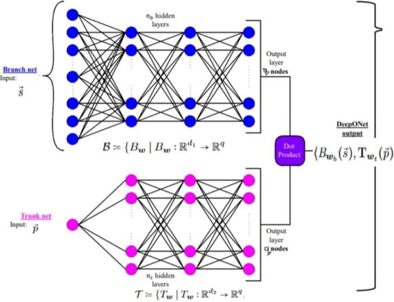

```python
# Define the model
class DeepONet:
    def __init__(self, branch_layers, trunk_layers):
        # Network initialization and evaluation functions
        self.branch_init, self.branch_apply = MLP(branch_layers, activation=np.tanh)  # or Relu
        self.trunk_init, self.trunk_apply = MLP(trunk_layers, activation=np.tanh)     # or Relu

        # Initialize
        branch_params = self.branch_init(rng_key = random.PRNGKey(1234))
        trunk_params = self.trunk_init(rng_key = random.PRNGKey(4321))
        params = (branch_params, trunk_params)

        # Use optimizers to set optimizer initialization and update functions
        self.opt_init, \
        self.opt_update, \
        self.get_params = optimizers.adam(optimizers.exponential_decay(1e-3,
                                                                      decay_steps=2000,
                                                                      decay_rate=0.9))
        self.opt_state = self.opt_init(params)

        # Used to restore the trained model parameters
        _, self.unravel_params = ravel_pytree(params)

        self.itercount = itertools.count()

        # Loggers
        self.loss_log = []

    # Define DeepONet architecture
    def operator_net(self, params, branch_input, x, t):
        branch_params, trunk_params = params
        y = np.stack([x, t])
        B = self.branch_apply(branch_params, branch_input)
        T = self.trunk_apply(trunk_params, y)
        outputs = np.sum(B * T)
        return  outputs

    # Define operator loss
    def loss_operator(self, params, batch):
        inputs, outputs = batch
        branch_input, y = inputs
        # Compute forward pass
        s_pred = vmap(self.operator_net, (None, 0, 0, 0))(params, branch_input, y[:,0], y[:,1])
        # Compute loss
        loss = np.mean((outputs.flatten() - s_pred.flatten())**2)
        return loss

    # Define a compiled update step
    @partial(jit, static_argnums=(0,))
    def step(self, i, opt_state, batch):
        params = self.get_params(opt_state)
        g = grad(self.loss_operator)(params, batch)
        return self.opt_update(i, g, opt_state)

    # Optimize parameters in a loop
    def train(self, dataset, nIter = 10000):
        # Define data iterators
        data_iterator = iter(dataset)

        pbar = trange(nIter)
        # Main training loop
        for it in pbar:
            # Fetch data
            batch = next(data_iterator)

            self.opt_state = self.step(next(self.itercount), self.opt_state, batch)

            if it % 1 == 0:
                params = self.get_params(self.opt_state)

                # Compute loss
                loss_value = self.loss_operator(params, batch)

                # Store loss
                self.loss_log.append(loss_value)

                # Print loss
                pbar.set_postfix({'Loss': loss_value})

    # Evaluates predictions at test points
    @partial(jit, static_argnums=(0,))
    def predict_s(self, params, U_star, Y_star):
        s_pred = vmap(self.operator_net, (None, 0, 0, 0))(params, U_star, Y_star[:,0], Y_star[:,1])
        return s_pred


    def get_params_count(self):
      params = self.get_params(self.opt_state)
      return sum(p.size for p in jax.tree_flatten(params)[0])
```

# Solving the PDE for Random Forcing Functions

```python
# Use double precision to generate data (due to GP sampling)

def RBF(x1, x2, params):
    output_scale, lengthscales = params
    diffs = np.expand_dims(x1 / lengthscales, 1) - \
            np.expand_dims(x2 / lengthscales, 0)
    r2 = np.sum(diffs**2, axis=2)
    return output_scale * np.exp(-0.5 * r2)


"""
def RBF(x1, x2, params): - This is a function definition statement that defines a function named RBF that takes in three parameters: x1, x2, and params.

1.output_scale, lengthscales = params
 - This line unpacks the params tuple into two variables: output_scale and lengthscales.
 These variables correspond to the output scale and length scales of the radial basis function (RBF) kernel.

2. diffs = np.expand_dims(x1 / lengthscales, 1) - np.expand_dims(x2 / lengthscales, 0) -
This line computes the differences between the inputs x1 and x2, normalized by the length scales.
It does this by first dividing x1 and x2 by the lengthscales array, then adding an extra dimension
 to each using np.expand_dims so that they can be broadcasted properly. The resulting array diffs has shape (N1, N2, D), where N1 is the number of points in x1,
 N2 is the number of points in x2, and D is the dimensionality of the input space.

3.r2 = np.sum(diffs**2, axis=2) -
This line computes the squared Euclidean distances between the normalized input points in x1 and x2.
It does this by squaring the elements of diffs and summing them along the last axis (i.e., the D axis). The resulting array r2 has shape (N1, N2).

4. return output_scale * np.exp(-0.5 * r2) -
This line applies the RBF kernel to the normalized input points in x1 and x2. It does this
 by exponentiating the negative squared distances between the points, scaled by a factor of -0.5,
 and multiplying the result by the output scale output_scale. The resulting array is a Gram matrix
 that describes the covariance between the points in x1 and x2."""
```

[output not shown]

## Solve ADR()

```python
def solve_ADR(key,m,Nx, Nt, length_scale):
    """Solve 1D
    u_t = (k(x) u_x)_x - v(x) u_x + g(u) + f(x)
    with zero initial and boundary conditions.
    """
    xmin, xmax = 0,1
    tmin, tmax = 0,1
    k = lambda x: 0.01*np.ones_like(x)
    v = lambda x: np.zeros_like(x)
    g = lambda u: 0.01*u ** 2
    dg = lambda u: 0.02 * u
    u0 = lambda x: np.zeros_like(x)

    # Generate subkeys
    subkeys = random.split(key, 2)

    # Generate a GP sample
    gp = 512
    gp_params = (1.0, length_scale)
    jitter = 1e-10
    X = np.linspace(xmin, xmax, gp)[:,None]
    K = RBF(X, X, gp_params)
    L = np.linalg.cholesky(K + jitter*np.eye(gp))
    gp_sample = np.dot(L, random.normal(subkeys[0], (gp,)))
    # Create a callable interpolation function
    f_fn = lambda x: np.interp(x, X.flatten(), gp_sample) #forcing function

    # Create grid
    x = np.linspace(xmin, xmax, Nx)
    t = np.linspace(tmin, tmax, Nt)
    h = x[1] - x[0]
    dt = t[1] - t[0]
    h2 = h ** 2

    # Compute coefficients and forcing
    k = k(x)
    v = v(x)
    f = f_fn(x)

    # Compute finite difference operators
    D1 = np.eye(Nx, k=1) - np.eye(Nx, k=-1)
    D2 = -2 * np.eye(Nx) + np.eye(Nx, k=-1) + np.eye(Nx, k=1)
    D3 = np.eye(Nx - 2)
    M = -np.diag(D1 @ k) @ D1 - 4 * np.diag(k) @ D2
    m_bond = 8 * h2 / dt * D3 + M[1:-1, 1:-1]
    v_bond = 2 * h * np.diag(v[1:-1]) @ D1[1:-1, 1:-1] + 2 * h * np.diag(
        v[2:] - v[: Nx - 2]
    )
    mv_bond = m_bond + v_bond
    c = 8 * h2 / dt * D3 - M[1:-1, 1:-1] - v_bond

    # Initialize solution and apply initial condition
    u = np.zeros((Nx, Nt))
    u = u.at[:,0].set(u0(x))
    #u = index_update(u, index[:,0], u0(x))
    # Time-stepping update
    def body_fn(i, u):
        gi = g(u[1:-1, i])
        dgi = dg(u[1:-1, i])
        h2dgi = np.diag(4 * h2 * dgi)
        A = mv_bond - h2dgi
        b1 = 8 * h2 * (0.5 * f[1:-1] + 0.5 * f[1:-1] + gi)
        b2 = (c - h2dgi) @ u[1:-1, i].T
        u = u.at[1:-1, i + 1].set(np.linalg.solve(A, b1 + b2))
        #u = index_update(u, index[1:-1, i + 1], np.linalg.solve(A, b1 + b2))
        return u

    """
    the body_fn function takes the current solution u at the previous time step,
    computes the right-hand side of the PDE, constructs the linear system
    of equations to be solved, and updates the solution u at the current time step.
    This process is repeated for all time steps until the final solution is obtained.
    """

    # Run loop
    u = lax.fori_loop(0, Nt-1, body_fn, u)

    """
    def fori_loop(lower, upper, body_fun, init_val):
      val = init_val
    for i in range(lower, upper):
      val = body_fun(i, val)
    return val



    """




    # Input sensor locations and measurements
    xx = np.linspace(xmin, xmax, m)
    branch_input = f_fn(xx) # branch input corresponding to the interpolated function


    # Output sensor locations and measurements
    # s = u[idx[:,0], idx[:,1]]
    s = u
    P = Nx*Nt
    x_idx = np.arange(Nx)
    t_idx = np.arange(Nt)
    idx = np.array([(i,j) for i in x_idx for j in t_idx])
    """
    The idx array now has a shape of (Nx*Nt, 2) where each row represents the indices of a point to be sampled.
    The values of idx are generated deterministically using np.arange() to create an array of indices along each dimension,
    which are then combined using np.array() to create a grid of all possible (x, t) pairs.
    """
    y = np.concatenate([x[idx[:,0]][:,None], t[idx[:,1]][:,None]], axis=1)



    # x, t: sampled points on grid
    return (x, t, u), (branch_input, y, s)
```

# Generating Training Data

```python
# # Geneate training data corresponding to one input sample
def generate_one_training_data(key, Nx,Nt):
    P = Nx*Nt
    # Numerical solution
    (x, t, u), (branch_input, y, s) = solve_ADR(key, m, Nx , Nt, length_scale)


    branch_input = np.tile(branch_input, (P, 1))

    return branch_input, y, s

# Geneate training data corresponding to N input sample
def generate_training_data(key, N, Nx, Nt):
    config.update("jax_enable_x64", True)
    P = Nx * Nt
    keys = random.split(key, N)
    #u_train, y_train, s_train = vmap(generate_one_training_data, (0, None, None))(keys, np.ones((N, P, Nx)), np.ones((N, P, Nt)))

    u_train, y_train, s_train = vmap(generate_one_training_data, (0, None, None))(keys, Nx, Nt)

    u_train = np.float32(u_train.reshape(N * P, -1))
    y_train = np.float32(y_train.reshape(N * P, -1))
    s_train = np.float32(s_train.reshape(N * P, -1))

    config.update("jax_enable_x64", False)
    return u_train, y_train, s_train

# Generate test data corresponding to one input sample
def generate_one_test_data(key, Nx,Nt):
    P = Nx*Nt
    (x, t, u), (branch_input, y, s) = solve_ADR(key,m, Nx , Nt,length_scale)

    XX, TT = np.meshgrid(x, t)

    u_test = np.tile(branch_input, (P, 1)) # may be it will not be P**2
    y_test = np.hstack([XX.flatten()[:,None], TT.flatten()[:,None]])
    s_test = u.T.flatten()

    return u_test, y_test, s_test

# Generate test data corresponding to N input sample
def generate_test_data(key, N, Nx, Nt):
    P = Nx*Nt

    config.update("jax_enable_x64", True)
    keys = random.split(key, N)

    u_test, y_test, s_test = vmap(generate_one_test_data, (0,None, None))(keys, Nx, Nt)

    u_test = np.float32(u_test.reshape(N * P, -1))
    y_test = np.float32(y_test.reshape(N * P, -1))
    s_test = np.float32(s_test.reshape(N * P, -1))

    config.update("jax_enable_x64", False)
    return u_test, y_test, s_test
```

## Computing The Errror

```python
# Compute relative l2 error over N test samples.
def compute_error(key, Nx,Nt):
    P = Nx*Nt
    # Generate one test sample
    u_test, y_test, s_test = generate_test_data(key, 1, Nx,Nt)
    # Predict
    s_pred = model.predict_s(params, u_test, y_test)[:,None]
    # Compute relative l2 error
    error_s = np.linalg.norm(s_test - s_pred) / np.linalg.norm(s_test)
    return error_s
```